# carAccident_2017(작성중)

Kim tae hyo

2018 8 2

### 1. 개 요

- 2017년 전국 자동차 사고에 관련된 데이터를 바탕으로 분석 및 예측을 실습해 보자.
- 공공데이터(https://www.data.go.kr/dataset/15003493/fileData.do) 에서 자료를 다운 받을 수 있다.

### 2. 목 적

- 2017년간 일어난 자동차 사고를 통해 장소별, 시간별 특징을 분석해 본다.
- 머신러닝을 통한 중상자수를 예측해서 시간, 장소에 따른 응급출동대기 시스템 발전에 기여한다.

### 3. 분 석

- step 1 : read.csv()로 csv파일을 불러온다.

```r
# local에 저장한 경로
car_accident <- read.csv("/Users/hbk/data/car_accident.csv", stringsAsFactors = FALSE)
str(car_accident)
```

```
## 'data.frame':    4065 obs. of  27 variables:
##  $ 발생년               : int  2017 2017 2017 2017 2017 2017 2017 2017 2017 2017 ...
##  $ 발생년월일시         : int  2017010101 2017010102 2017010102 2017010102 2017010104 2017010104 2017010105 2017010109 2017010118 2017010120 ...
##  $ 발생분               : int  15 28 43 22 37 0 50 25 33 0 ...
##  $ 주야                 : chr  "야간" "야간" "야간" "야간" ...
##  $ 요일                 : chr  "일" "일" "일" "일" ...
##  $ 사망자수             : int  1 1 1 1 1 1 1 1 1 1 ...
##  $ 사상자수             : int  2 1 2 1 1 2 1 5 3 7 ...
##  $ 중상자수             : int  1 0 0 0 0 1 0 3 1 4 ...
##  $ 경상자수             : int  0 0 1 0 0 0 0 1 1 2 ...
##  $ 부상신고자수         : int  0 0 0 0 0 0 0 0 0 0 ...
##  $ 발생지시도           : chr  "전남" "서울" "충남" "충남" ...
##  $ 발생지시군구         : chr  "장성군" "송파구" "홍성군" "아산시" ...
##  $ 사고유형_대분류      : chr  "차대차" "차대사람" "차대차" "차량단독" ...
##  $ 사고유형_중분류      : chr  "기타" "횡단중" "추돌" "공작물충돌" ...
##  $ 사고유형             : chr  "기타" "횡단중" "추돌" "공작물충돌" ...
##  $ 법규위반_대분류      : chr  "운전자법규위반" "운전자법규위반" "운전자법규위반" "운전자법규위반" ...
##  $ 법규위반             : chr  "안전운전 의무 불이행" "안전운전 의무 불이행" "안전운전 의무 불이행" "안전운전 의무 불이행" ...
##  $ 도로형태_대분류      : chr  "단일로" "교차로" "단일로" "단일로" ...
##  $ 도로형태             : chr  "기타단일로" "교차로부근" "기타단일로" "기타단일로" ...
##  $ 당사자종별_1당_대분류: chr  "승용차" "승용차" "승용차" "승용차" ...
##  $ 당사자종별_1당       : chr  "승용차" "승용차" "승용차" "승용차" ...
##  $ 당사자종별_2당_대분류: chr  "승용차" "보행자" "승용차" "없음" ...
##  $ 당사자종별_2당       : chr  "승용차" "보행자" "승용차" "없음" ...
##  $ 발생위치X_UTMK       : num  933501 967570 916497 961608 946778 ...
##  $ 발생위치Y_UTMK       : num  1700129 1944453 1842880 1864573 1941695 ...
##  $ 경도                 : num  127 127 127 127 127 ...
##  $ 위도                 : num  35.3 37.5 36.6 36.8 37.5 ...
```

- step 2 : 데이터 전처리

```r
# 분석에 필요없는 컬럼 제거
car_accident[c("발생년","부상신고자수","사고유형_중분류","사고유형","법규위반_대분류","법규위반","도로형태_대분류","도로형태","당사자종별_1당_대분류","당사자종별_1당","당사자종별_2당_대분류","당사자종별_2당","발생위치X_UTMK","발생위치Y_UTMK")] <- NULL

# mdt : month day time
car_accident$mdt <- (car_accident$발생년월일시 - 2017000000) * 100 + car_accident$발생분

# 기존에 월일시, 분 컬럼은 제거
car_accident[c("발생년월일시","발생분")] <- NULL

# mdt를 첫번째 컬럼으로 수정
car_accident <- car_accident[c(12,1:11)]
str(car_accident)
```

```
## 'data.frame':    4065 obs. of  12 variables:
##  $ mdt            : num  1010115 1010228 1010243 1010222 1010437 ...
##  $ 주야           : chr  "야간" "야간" "야간" "야간" ...
##  $ 요일           : chr  "일" "일" "일" "일" ...
##  $ 사망자수       : int  1 1 1 1 1 1 1 1 1 1 ...
##  $ 사상자수       : int  2 1 2 1 1 2 1 5 3 7 ...
##  $ 중상자수       : int  1 0 0 0 0 1 0 3 1 4 ...
##  $ 경상자수       : int  0 0 1 0 0 0 0 1 1 2 ...
##  $ 발생지시도     : chr  "전남" "서울" "충남" "충남" ...
##  $ 발생지시군구   : chr  "장성군" "송파구" "홍성군" "아산시" ...
##  $ 사고유형_대분류: chr  "차대차" "차대사람" "차대차" "차량단독" ...
##  $ 경도           : num  127 127 127 127 127 ...
##  $ 위도           : num  35.3 37.5 36.6 36.8 37.5 ...
```

- step 3. 장소별 분석

```r
#install.packages("ggmap")
library(ggmap)
```

```r
#install.packages("doBy")
library(doBy)
```

```r
# 발생지시도를 기준으로 사고발생한 횟수를 집계한다
a <- aggregate(mdt~발생지시도, car_accident, length)
colnames(a) <- c("장소","횟수")
b <- orderBy(~-횟수,a)
rownames(b) <- NULL
b
```

```
##    장소 횟수
## 1  경기  766
## 2  경북  412
## 3  전남  370
## 4  충남  338
## 5  서울  335
## 6  경남  324
## 7  전북  300
## 8  강원  226
## 9  충북  223
## 10 부산  161
## 11 대구  146
## 12 광주  117
## 13 인천  103
## 14 대전   84
## 15 제주   78
## 16 울산   64
## 17 세종   18
```

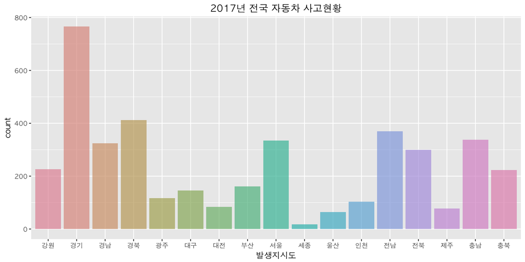

```r
# 막대그래프
library(ggplot2)
library(colorspace)
ggplot(car_accident)+
  geom_bar(aes(x=발생지시도), fill = rainbow_hcl(17), alpha = .7)+
  labs(title = "2017년 전국 자동차 사고현황")+
  theme(plot.title=element_text(hjust=0.5))
```

```r
# 위에서 구한 집계값을 추가한다
car <- merge(car_accident, b, by.x = "발생지시도", by.y = "장소")
car <- orderBy(~mdt, car)
rownames(car) <- NULL
```

[figure not shown]

```r
# 지도를 통한 시각화
southKorea <- get_map(location = c(128,36), zoom = 7, maptype = "roadmap", color = "bw")
ggmap(southKorea)+
  geom_point(data = car, aes(x = 경도, y = 위도, col = 횟수), size = .5, alpha = .5)
```

- step 4. 시간별 분석

```r
# mdt 문자로 변환
car$mdt <- as.character(car$mdt)

# m : month
m <- NULL
for (i in 1:NROW(car)){
  m <- c(m,substr(car$mdt[i],1,nchar(car$mdt[i])-6))
}
car$m <-factor(m,c("1","2","3","4","5","6","7","8","9","10","11","12"))
```

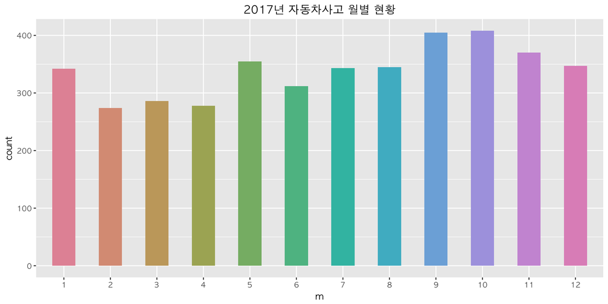

```r
# 월별 자동차 사고
ggplot(car)+
  geom_bar(aes(x=m), fill = rainbow_hcl(12), width = .5)+
  ggtitle("2017년 자동차사고 월별 현황")+
  theme(plot.title=element_text(hjust=0.5))
```

10월달에 사고가 제일 많이 일어났다는걸 알수 있다.

```r
death_m <- aggregate(사망자수~m, car, sum)
orderBy(~-사망자수,death_m)
```

```
##     m 사망자수
## 10 10      420
## 9   9      419
## 11 11      379
## 5   5      366
## 7   7      357
## 12 12      355
## 1   1      353
## 8   8      353
## 6   6      315
## 3   3      295
## 4   4      293
## 2   2      280
```

역시나 사망자수도 10월이 제일 많았다.(삼가 고인의 명복을 빕니다.) 그럼 왜 하필 10월일까? 곰곰이 생각을 해보면 10월은 계절로 치면 가을에 속하고 이때 수학여행, 등산여행, 단풍구경 등 단체관광이 증가하는 시기이다. 그래서 사고발생시 대형사고로 이어지기 쉽기 때문이다.

- step 5. 시간-장소 분석

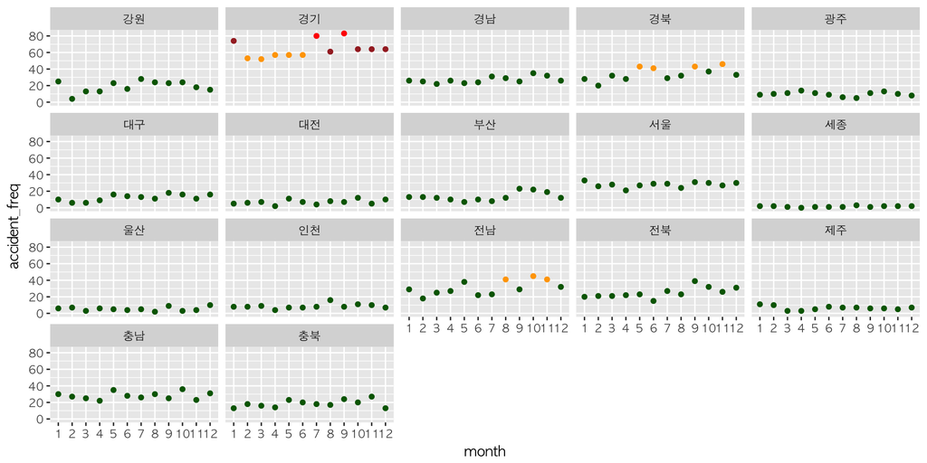

```r
m <- table(car$m, car$발생지시도)
m <- as.data.frame(m)
ggplot(m)+
  geom_point(aes(x=Var1,y=Freq),
             col=ifelse(m$Freq >= 80, "red",  # 80이상이면 빨간
                        ifelse(m$Freq >= 60,"brown",  # 60이상이면 갈색
                               ifelse(m$Freq >= 40,"orange","darkgreen"))))+  # 40이상이면 오렌지
  facet_wrap(~Var2)+
  labs(x="month",y="accident_freq")
```

### 4. 머신러닝

- 사상자수 중상자수를 예측하는 모델을 만들어 보자.
- 자동차 사고에서 가장 중요한 것은 중상자수를 예측하는 것이다.

[1] 데이터 수집

```r
carML <- car[c("m","주야","요일","발생지시도","사고유형_대분류","사상자수")]
str(carML)
```

```
## 'data.frame':    4065 obs. of  6 variables:
##  $ m              : Factor w/ 12 levels "1","2","3","4",..: 1 1 1 1 1 1 1 1 1 1 ...
##  $ 주야           : chr  "야간" "야간" "야간" "야간" ...
##  $ 요일           : chr  "일" "일" "일" "일" ...
##  $ 발생지시도     : chr  "전남" "충남" "서울" "충남" ...
##  $ 사고유형_대분류: chr  "차대차" "차량단독" "차대사람" "차대차" ...
##  $ 사상자수       : int  2 1 1 2 2 1 1 5 3 7 ...
```

[2] 데이터 탐구

```r
summary(carML)
```

```
##        m            주야               요일            발생지시도
##  10     : 408   Length:4065        Length:4065        Length:4065
##  9      : 405   Class :character   Class :character   Class :character
##  11     : 370   Mode  :character   Mode  :character   Mode  :character
##  5      : 355
##  12     : 347
##  8      : 345
##  (Other):1835
##  사고유형_대분류       사상자수
##  Length:4065        Min.   :  1.000
##  Class :character   1st Qu.:  1.000
##  Mode  :character   Median :  1.000
##                     Mean   :  1.572
##                     3rd Qu.:  2.000
##                     Max.   :105.000
##
```

```r
attach(carML)
library()
```